# Black Friday Data Analysis to Predict Purhcasing power of the customers.

## Question 1) What are we doing ?

### With this growing market of retail, we are going to do study the data from the black friday sales for Retail industry. We will put some lights on data to study the cases of markets demand and people's purchasing power.

## Question 2) Why are we doing this ?

### We are doing this for multiple reasons :-

### 1) To determine the strenght of purchasing power according to different section of the socity so that Retail Market can follow accoringly.

### 2) Companies should be aware of the product as in to which section they need to target according to the project Categories.

## Question 3) Target Customers :-

### We are doing this for the retail industry to determine their demand, their sales, purchasing power of the customers and puting the product categories correct for the competive sale.

## Question 4) What have we done?

### We Did Comparison between different models of regression and classification.

```
## Upon checking the Accuracy we moved ahead with Random forest.
```

```python
#In the above line we use the function of os library to fetch the file

#pandas has an 'options system' that lets you customize some aspects of its behaviour
#and display-related options being those the user is most likely to adjust.
#In the above line we want to display maximum 10 number of rows.

import pandas as pd
import matplotlib.pyplot as plt
import seaborn as sns
import os
from matplotlib import pyplot


from sklearn.model_selection import train_test_split
from sklearn.tree import DecisionTreeClassifier
from sklearn.metrics import accuracy_score

import os

from IPython.core.interactiveshell import InteractiveShell
InteractiveShell.ast_node_interactivity = "all"

from sklearn.model_selection import train_test_split
from sklearn.model_selection import GridSearchCV
from sklearn.model_selection import learning_curve
from sklearn.preprocessing import LabelEncoder
from sklearn.preprocessing import StandardScaler
from sklearn.ensemble import RandomForestRegressor
from sklearn.metrics import mean_squared_error


sns.set(style='ticks', context='talk')
#seaborn.set is used to set things like the color of the axes, whether a grid is enabled by default,
#and other aesthetic elements of the plot.
#In the above line we set style and context of the plot.

ap = pd.read_csv("/Users/anandchauhan/Downloads/Blackfriday.csv")
ap.head(10)
```

|  | User_ID | Product_ID | Gender | Age | Occupation | City_Category | Stay_In_Current_City_Years | Marital_Status | Product_Category_1 | Product_Category_2 | Product_Category_3 | Purchase |
| --- | --- | --- | --- | --- | --- | --- | --- | --- | --- | --- | --- | --- |
| 0 | 1000001 | P00069042 | F | 0-17 | 10 | A | 2 | 0 | 3 | NaN | NaN | 8370 |
| 1 | 1000001 | P00248942 | F | 0-17 | 10 | A | 2 | 0 | 1 | 6.0 | 14.0 | 15200 |
| 2 | 1000001 | P00087842 | F | 0-17 | 10 | A | 2 | 0 | 12 | NaN | NaN | 1422 |
| 3 | 1000001 | P00085442 | F | 0-17 | 10 | A | 2 | 0 | 12 | 14.0 | NaN | 1057 |
| 4 | 1000002 | P00285442 | M | 55+ | 16 | C | 4+ | 0 | 8 | NaN | NaN | 7969 |
| 5 | 1000003 | P00193542 | M | 26-35 | 15 | A | 3 | 0 | 1 | 2.0 | NaN | 15227 |
| 6 | 1000004 | P00184942 | M | 46-50 | 7 | B | 2 | 1 | 1 | 8.0 | 17.0 | 19215 |
| 7 | 1000004 | P00346142 | M | 46-50 | 7 | B | 2 | 1 | 1 | 15.0 | NaN | 15854 |
| 8 | 1000004 | P0097242 | M | 46-50 | 7 | B | 2 | 1 | 1 | 16.0 | NaN | 15686 |
| 9 | 1000005 | P00274942 | M | 26-35 | 20 | A | 1 | 1 | 8 | NaN | NaN | 7871 |

```python
ap.info()
```

```
<class 'pandas.core.frame.DataFrame'>
RangeIndex: 537577 entries, 0 to 537576
Data columns (total 12 columns):
User_ID                       537577 non-null int64
Product_ID                    537577 non-null object
Gender                        537577 non-null object
Age                           537577 non-null object
Occupation                    537577 non-null int64
City_Category                 537577 non-null object
Stay_In_Current_City_Years    537577 non-null object
Marital_Status                537577 non-null int64
Product_Category_1            537577 non-null int64
Product_Category_2            370591 non-null float64
Product_Category_3            164278 non-null float64
Purchase                      537577 non-null int64
dtypes: float64(2), int64(5), object(5)
memory usage: 49.2+ MB
```

```python
ap.isnull().sum()
```

```
User_ID                            0
Product_ID                         0
Gender                             0
Age                                0
Occupation                         0
City_Category                      0
Stay_In_Current_City_Years         0
Marital_Status                     0
Product_Category_1                 0
Product_Category_2            166986
Product_Category_3            373299
Purchase                           0
dtype: int64
```

```python
ap.columns
```

```
Index(['User_ID', 'Product_ID', 'Gender', 'Age', 'Occupation', 'City_Category',
       'Stay_In_Current_City_Years', 'Marital_Status', 'Product_Category_1',
       'Product_Category_2', 'Product_Category_3', 'Purchase'],
      dtype='object')
```

```python
ap.sort_values('User_ID').head(10)
ap['User_ID'].value_counts().count()   #5,891 customers
```

|  | User_ID | Product_ID | Gender | Age | Occupation | City_Category | Stay_In_Current_City_Years | Marital_Status | Product_Category_1 | Product_Category_2 | Product_Category_3 | Purchase |
| --- | --- | --- | --- | --- | --- | --- | --- | --- | --- | --- | --- | --- |
| 0 | 1000001 | P00069042 | F | 0-17 | 10 | A | 2 | 0 | 3 | NaN | NaN | 8370 |
| 390151 | 1000001 | P00255842 | F | 0-17 | 10 | A | 2 | 0 | 16 | NaN | NaN | 16446 |
| 390150 | 1000001 | P0097142 | F | 0-17 | 10 | A | 2 | 0 | 12 | NaN | NaN | 1715 |
| 350797 | 1000001 | P00289942 | F | 0-17 | 10 | A | 2 | 0 | 3 | 4.0 | 5.0 | 10900 |
| 311713 | 1000001 | P00210342 | F | 0-17 | 10 | A | 2 | 0 | 3 | 4.0 | NaN | 11039 |
| 311712 | 1000001 | P00248442 | F | 0-17 | 10 | A | 2 | 0 | 3 | 4.0 | NaN | 7943 |
| 311711 | 1000001 | P00051442 | F | 0-17 | 10 | A | 2 | 0 | 8 | 17.0 | NaN | 9938 |
| 311710 | 1000001 | P00183942 | F | 0-17 | 10 | A | 2 | 0 | 3 | 4.0 | NaN | 10872 |
| 311709 | 1000001 | P00178342 | F | 0-17 | 10 | A | 2 | 0 | 8 | NaN | NaN | 7887 |
| 467663 | 1000001 | P00058142 | F | 0-17 | 10 | A | 2 | 0 | 3 | 4.0 | 12.0 | 11051 |

```
5891
```

```python
ap['Gender'].unique()
```

```
array(['F', 'M'], dtype=object)
```

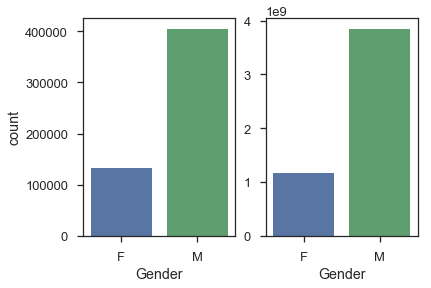

```python
#Checking For the purchasing power of the Customer based on the Gender.
plt.subplot(1,2,1)
sns.countplot(ap['Gender']) #attendance

m_purchase = ap.groupby(['Gender'])['Purchase'].sum()
plt.subplot(1,2,2)
sns.barplot(m_purchase.index, m_purchase.values) #dollar value
```

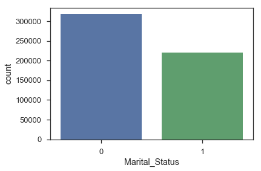

```python
#Checking For the purchasing power of the Customer based on the Marital Status.
sns.countplot(ap['Marital_Status'])
```

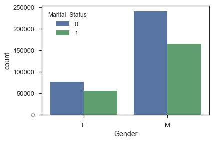

```python
#Checking For the purchasing power of the Customer based on the Marital Status and Gender.
sns.countplot(ap['Gender'], hue = ap['Marital_Status'])
```

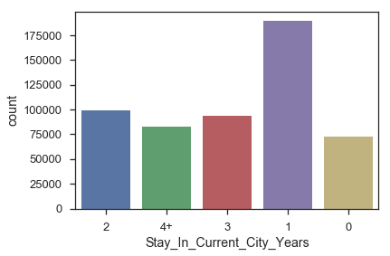

```python
##Checking For the purchasing power based on the City they are staying.
sns.countplot(ap['Stay_In_Current_City_Years'])
```

```python
##Customer Purchasing Behavior :- Now we are predicting the Item which has been purchased by the customer from each product categories.

ap['Product_ID'].value_counts().count()
ap['Product_Category_1'].value_counts(dropna = False).sort_index()
ap['Product_Category_2'].value_counts(dropna = False).sort_index()
ap['Product_Category_3'].value_counts(dropna = False).sort_index()

ap = ap.drop(['Product_ID', 'Product_Category_2', 'Product_Category_3'], axis = 1)
```

```
3623
```

```
1     138353
2      23499
3      19849
4      11567
5     148592
6      20164
7       3668
8     112132
9        404
10      5032
11     23960
12      3875
13      5440
14      1500
15      6203
16      9697
17       567
18      3075
Name: Product_Category_1, dtype: int64
```

[output not shown]

[output not shown]

```
Text(0.5,1,'Mean of the Purchases per Category')
```

```
Text(0.5,0,'Product Category')
```

```
Text(0,0.5,'Mean Purchase')
```

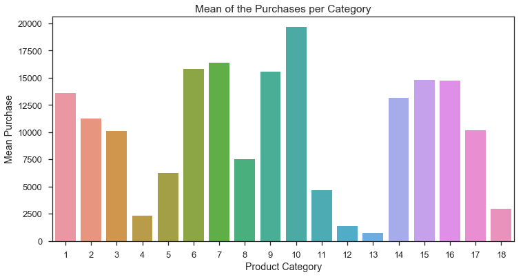

```python
category = []
mean_purchase = []


for i in ap['Product_Category_1'].unique():
    category.append(i)
category.sort()

for e in category:
    mean_purchase.append(ap[ap['Product_Category_1']==e]['Purchase'].mean())

plt.figure(figsize=(12,6))

sns.barplot(x=category,y=mean_purchase)
plt.title('Mean of the Purchases per Category')
plt.xlabel('Product Category')
plt.ylabel('Mean Purchase')
plt.show()
```

```
Text(0.5,1,'Mean of the Purchases per Category')
```

```
Text(0.5,0,'Product Category')
```

```
Text(0,0.5,'Mean Purchase')
```

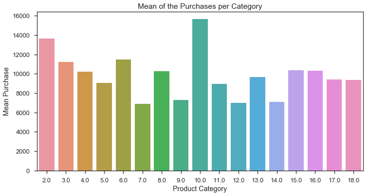

```python
ap = pd.read_csv("/Users/anandchauhan/Downloads/Blackfriday.csv")

category = []
mean_purchase = []


for i in ap['Product_Category_2'].unique():
    category.append(i)
category.sort()

for e in category:
    mean_purchase.append(ap[ap['Product_Category_2']==e]['Purchase'].mean())

plt.figure(figsize=(12,6))

sns.barplot(x=category,y=mean_purchase)
plt.title('Mean of the Purchases per Category')
plt.xlabel('Product Category')
plt.ylabel('Mean Purchase')
plt.show()
```

```
Text(0.5,1,'Mean of the Purchases per Category')
```

```
Text(0.5,0,'Product Category')
```

```
Text(0,0.5,'Mean Purchase')
```

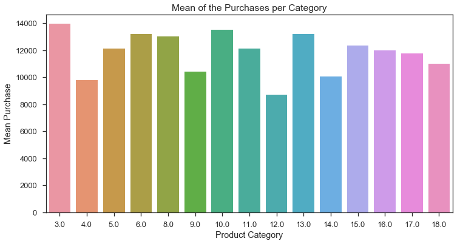

```python
category = []
mean_purchase = []


for i in ap['Product_Category_3'].unique():
    category.append(i)
category.sort()

for e in category:
    mean_purchase.append(ap[ap['Product_Category_3']==e]['Purchase'].mean())

plt.figure(figsize=(12,6))

sns.barplot(x=category,y=mean_purchase)
plt.title('Mean of the Purchases per Category')
plt.xlabel('Product Category')
plt.ylabel('Mean Purchase')
plt.show()
```

[output not shown]

```
(-1.2226991602919128,
 1.222298593133692,
 -1.2074491491645465,
 1.1376882037659544)
```

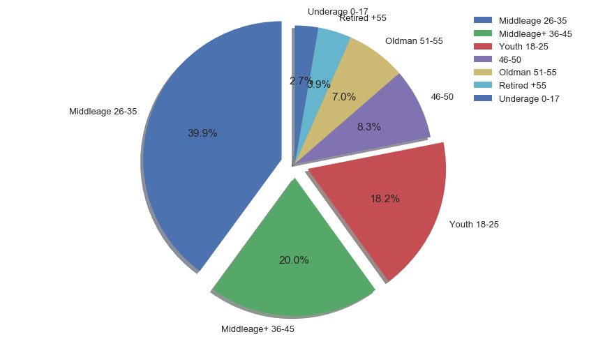

```python
#Age ratio to ensure purchase.

label=['Middleage 26-35','Middleage+ 36-45','Youth 18-25','46-50','Oldman 51-55','Retired +55','Underage 0-17']
explode = (0.1, 0.1, .1, 0,0,0,0)
fig1, ax1 = plt.subplots(figsize=(12,7))
ax1.pie(ap['Age'].value_counts(), explode=explode, labels=label, autopct='%1.1f%%',
        shadow=True, startangle=90)
# Equal aspect ratio ensures that pie is drawn as a circle
ax1.axis('equal')
plt.tight_layout()
plt.legend()
plt.show()
```

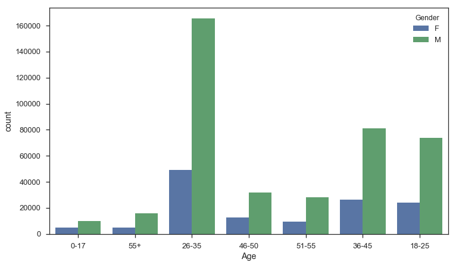

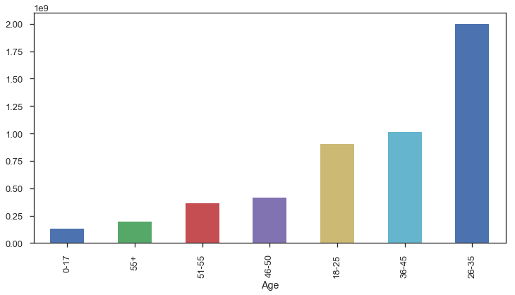

```python
#Purchaing power based on Age Group.

fig1, ax1 = plt.subplots(figsize=(12,7))
sns.countplot(ap['Age'],hue=ap['Gender'])

def plot(group,column,plot):
    ax=plt.figure(figsize=(12,6))
    ap.groupby(group)[column].sum().sort_values().plot(plot)
plot('Age','Purchase','bar')
```